# ExtraaLearn Project

## Visualizing the Decision Tree

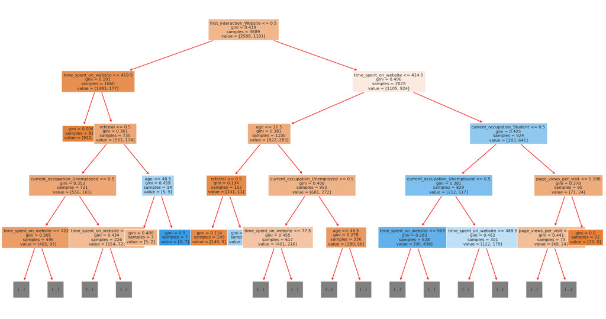

```python
feature_name = list(X_train.columns)
plt.figure(figsize=(21,11))
out = tree.plot_tree(
    estimator,
    max_depth=4,
    feature_names = feature_name,
    fontsize=8,
    filled = True,
    node_ids=False,
    class_names=None
)
# adding arrows to the decision tress split if they are missing
for a in out:
  arrow = a.arrow_patch
  if arrow is not None:
    arrow.set_edgecolor('red')
    arrow.set_linewidth(1)
plt.show()
```

## Feature Importance

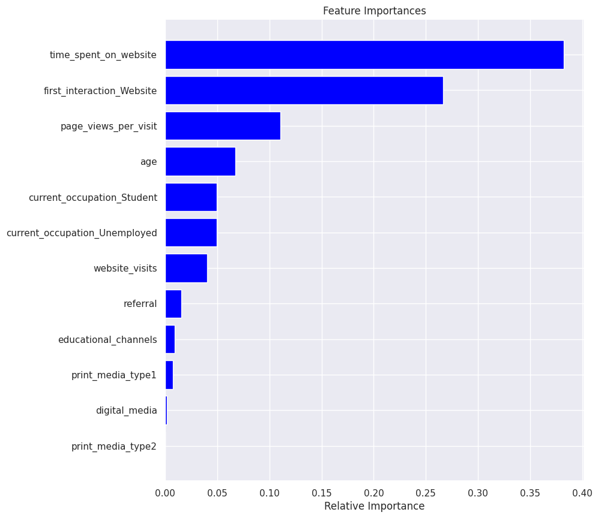

```python
# Importance of features in the tree building
importances = estimator.feature_importances_
indices = np.argsort(importances)

plt.figure(figsize=(9, 10))
plt.title("Feature Importances")
plt.barh(range(len(indices)), importances[indices], color="blue", align="center")
plt.yticks(range(len(indices)), [feature_name[i] for i in indices])
plt.xlabel("Relative Importance")
plt.show()
```

- The model performance has been generalized.
- By the graph, we can say that the important features are:
  1. Time spent on the website
  2. First interaction through the website
  3. Page views per visit

## Do we need to prune the tree?

Since the recall score of the decision tree model is 59%, we need to prune the tree.

## Building a Random Forest model

```python
rf_estimator = RandomForestClassifier(random_state=1)
rf_estimator.fit(X_train, y_train)
```

```
RandomForestClassifier(random_state=1)
```

```
              precision    recall  f1-score   support

           0       1.00      1.00      1.00      2588
           1       1.00      0.99      1.00      1101

    accuracy                           1.00      3689
   macro avg       1.00      1.00      1.00      3689
weighted avg       1.00      1.00      1.00      3689
```

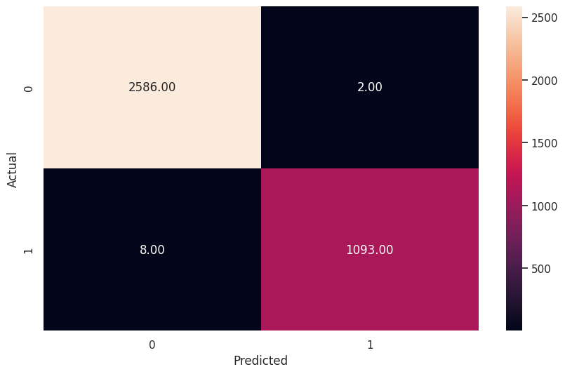

```python
# Performance on the training data
y_pred_train_rf = rf_estimator.predict(X_train)
metrics_score(y_train, y_pred_train_rf)
```

**Observations:**

- The model correctly fits all the parameters
- Alomst 0 erros on the training set.

```
              precision    recall  f1-score   support

           0       0.83      0.91      0.87       647
           1       0.74      0.58      0.65       276

    accuracy                           0.81       923
   macro avg       0.79      0.74      0.76       923
weighted avg       0.81      0.81      0.80       923
```

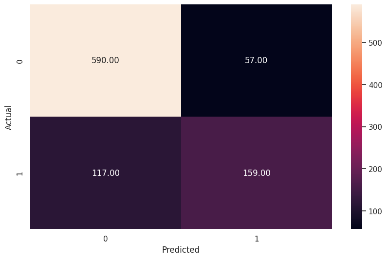

```python
# Performance on testing data
y_pred_test_rf = rf_estimator.predict(X_test)
metrics_score(y_test, y_pred_test_rf)
```

**Observations:**

- The model has a low recall score of 58%
- It also seems that the model is overfitting the data.

## Feature Importance

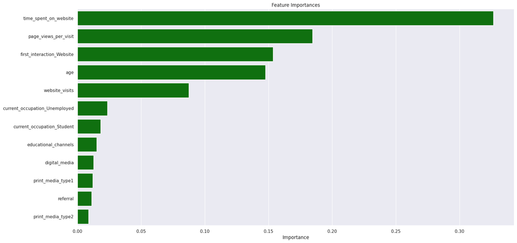

```python
importances = rf_estimator.feature_importances_
columns = X_train.columns
importance_df = pd.DataFrame(importances, index=columns, columns = ['Importance']).sort_values(ascending = False, by = 'Importance')

plt.figure(figsize=(20,10))
plt.title("Feature Importances")
sns.barplot(x=importance_df.Importance, y=importance_df.index, color='green')
plt.show()
```

## Actionable Insights and Recommendations

**Insights:**

- We can predict that if a lead is on the website for a longer time, the chances of him/her to becoming a paid lead is higher.
- Even the first impression that the lead gets through his first interaction is an important factor to tconvert the lead into a paid lead.
- Leads who visit the website many times which indicate that they are going to enter the paid subscription.